# eda_final_(1)

Drive engType

```python
# lets Drop the duplicate Value

carsales.drop_duplicates(inplace=True)
carsales.shape
```

```
(9463, 10)
```

6.1 Fixing engV missing / erroneous values

```python
#Function that removes the outlier entries of engV and returns dataframe

def exclude_outliers_for_engV():
    return pd.DataFrame(carsales[(carsales.engV > 0.5) & (carsales.engV < 25)])

# Function that computes the mean value of engV based on make and model

def compute_engV_mean(r):
    car_make = r.name[0]
    car_model = r.name[1]
    if r.count() > 0:
        return round(r.mean(),2)
    else:
        engV_df = exclude_outliers_for_engV()
        engV_make = engV_df[engV_df.car == car_make].engV
        if engV_make.count() > 0:
            return round(engV_make.mean(),2)
        else:
            return round(engV_df.engV.mean(),2)


#Create a staging "engV mean" dataframe for  all combinations of make and model

engV_mean = carsales.groupby(['car','model']).engV.apply(compute_engV_mean).reset_index()
engV_mean.rename(columns={'engV':'engV_avg'}, inplace=True)
engV_mean.head(5)
```

|  | car | model | engV_avg |
| --- | --- | --- | --- |
| 0 | Acura | MDX | 3.62 |
| 1 | Acura | RL | 3.50 |
| 2 | Acura | TL | 3.20 |
| 3 | Acura | TLX | 2.40 |
| 4 | Acura | ZDX | 3.70 |

```python
'''
Function that return engV value for missing records
'''
def get_missing_engV(r):
    if pd.isnull(r.engV):
        return engV_mean[(engV_mean.car == r.car) & (engV_mean.model == r.model)].engV_avg.values[0]
    else:
        return r.engV


'''
Fix the missing engV values
'''
print('--------------Before fix-----------------')
print(carsales[carsales.engV.isnull()].shape)

carsales.engV = carsales.apply(get_missing_engV, axis=1)
print('--------------After fix -----------------')
print(carsales[carsales.engV.isnull()].shape)
```

```
--------------Before fix-----------------
(434, 10)
--------------After fix -----------------
(0, 10)
```

6.2 Fixing price missing / erroneous values

```python
#Function that computes the median value of price based on make and model

def compute_price_median(r):
    car_make = r.name[0]
    car_model = r.name[1]
    if (r.count() > 0) & (r.median() > 0):
        return r.median()
    else:
        price_make = carsales[carsales.car == car_make].price
        if price_make.median() > 0:
            return price_make.median()
        else:
            return carsales.price.median()


'''
Create a staging "Price median" dataframe for  all combinations of make and model
'''
price_median = carsales.groupby(['car','model']).price.apply(compute_price_median).reset_index()
price_median.rename(columns={'price':'price_median'}, inplace=True)
price_median.head(5)
```

|  | car | model | price_median |
| --- | --- | --- | --- |
| 0 | Acura | MDX | 17200.0 |
| 1 | Acura | RL | 13950.0 |
| 2 | Acura | TL | 8699.0 |
| 3 | Acura | TLX | 38200.0 |
| 4 | Acura | ZDX | 30999.0 |

```python
# Function that return price value for missing records

def get_missing_price(r):
    if r.price == 0:
        return price_median[(price_median.car == r.car) & (price_median.model == r.model)].price_median.values[0]
    else:
        return r.price


# Fix the missing price values

print('--------------Before fix-----------------')
print(carsales[carsales.price == 0].shape)

carsales.price = carsales.apply(get_missing_price, axis=1)
print('--------------After fix -----------------')
print(carsales[carsales.price == 0].shape)
```

```
--------------Before fix-----------------
(240, 10)
--------------After fix -----------------
(0, 10)
```

6.3 Fixing mileage missing / erroneous values

```python
# Function that computes the median value of mileage based on make and model

def compute_mileage_median(r):
    car_make = r.name[0]
    car_model = r.name[1]
    if (r.count() > 0) & (r.median() > 0):
        return r.median()
    else:
        mileage_make = carsales[carsales.car == car_make].mileage
        if mileage_make.median() > 0:
            return mileage_make.median()
        else:
            return carsales.mileage.median()



# Create a staging "mileage median" dataframe for  all combinations of make and model

mileage_median = carsales.groupby(['car','model']).mileage.apply(compute_mileage_median).reset_index()
mileage_median.rename(columns={'mileage':'mileage_median'}, inplace=True)
mileage_median.head(5)
```

|  | car | model | mileage_median |
| --- | --- | --- | --- |
| 0 | Acura | MDX | 85.0 |
| 1 | Acura | RL | 138.0 |
| 2 | Acura | TL | 145.0 |
| 3 | Acura | TLX | 4.0 |
| 4 | Acura | ZDX | 32.0 |

```python
# Function that return mileage value for missing records

def get_missing_mileage(r):
    if r.mileage == 0:
        return mileage_median[(mileage_median.car == r.car) & (mileage_median.model == r.model)].mileage_median.values[0]
    else:
        return r.mileage



# Fix the missing price values

print('--------------Before fix-----------------')
print(carsales[carsales.mileage == 0].shape)

carsales.mileage = carsales.apply(get_missing_mileage, axis=1)
print('--------------After fix -----------------')
print(carsales[carsales.mileage == 0].shape)
```

```
--------------Before fix-----------------
(310, 10)
--------------After fix -----------------
(0, 10)
```

6.4 Fixing drive missing / erroneous values

```python
# Function that removes the null entries of drive and returns dataframe

def get_clensed_data_for_drive():
    return pd.DataFrame(carsales[carsales.drive.isnull() == False])



# Function that computes the mode value of drive based on make and model

def compute_drive(r):
    car_make = r.name[0]
    car_model = r.name[1]
    if r.count() > 0:
        return r.mode()
    else:
        drive_df = get_clensed_data_for_drive()
        drive_make = drive_df[drive_df.car == car_make].drive
        if drive_make.count() > 0:
            return drive_make.mode()
        else:
            return drive_df.drive.mode()



# Create a staging "drive mode" dataframe for  all combinations of make and model

drive_mode = carsales.groupby(['car','model']).drive.apply(compute_drive).reset_index()
drive_mode.rename(columns={'drive':'drive_mode'}, inplace=True)
drive_mode.drop('level_2', axis=1)
```

|  | car | model | drive_mode |
| --- | --- | --- | --- |
| 0 | Acura | MDX | full |
| 1 | Acura | RL | full |
| 2 | Acura | TL | front |
| 3 | Acura | TLX | front |
| 4 | Acura | ZDX | full |
| ... | ... | ... | ... |
| 914 | ZX | LandMark | full |
| 915 | ËUAZ | 1301 | full |
| 916 | ËUAZ | 1302 | full |
| 917 | ËUAZ | 969 Âîëûíü | full |
| 918 | ËUAZ | 969Ì | full |

919 rows × 3 columns

```python
# Function that return drive value for missing records

def get_missing_drive(r):
    if pd.isnull(r.drive):
        return drive_mode[(drive_mode.car == r.car) & (drive_mode.model == r.model)].drive_mode.values[0]
    else:
        return r.drive

# Fix the missing drive values

print('--------------Before fix-----------------')
print(carsales[carsales.drive.isnull()].shape)

carsales.drive = carsales.apply(get_missing_drive, axis=1)
print('--------------After fix -----------------')
print(carsales[carsales.drive.isnull()].shape)
```

```
--------------Before fix-----------------
(510, 10)
--------------After fix -----------------
(0, 10)
```

6.5 Fixing engType missing / erroneous values

```python
#Function that removes the null entries of engType and returns dataframe

def get_clensed_data_for_engType():
    return pd.DataFrame(carsales[carsales.engType.isnull() == False])



#Function that computes the mode value of engType based on make and model

def compute_engType(r):
    car_make = r.name[0]
    car_model = r.name[1]
    if r.count() > 0:
        return r.mode()
    else:
        engType_df = get_clensed_data_for_engType()
        engType_make = engType_df[engType_df.car == car_make].engType
        if engType_make.count() > 0:
            return engType_make.mode()
        else:
            return engType_df.engType.mode()



#Create a staging "engType mode" dataframe for  all combinations of make and model

engType_mode = carsales.groupby(['car','model']).engType.apply(compute_engType).reset_index()
engType_mode.rename(columns={'engType':'engType_mode'}, inplace=True)
engType_mode.drop('level_2', axis=1)
```

|  | car | model | engType_mode |
| --- | --- | --- | --- |
| 0 | Acura | MDX | Petrol |
| 1 | Acura | RL | Gas |
| 2 | Acura | TL | Gas |
| 3 | Acura | TLX | Petrol |
| 4 | Acura | ZDX | Other |
| ... | ... | ... | ... |
| 984 | ZX | LandMark | Petrol |
| 985 | ËUAZ | 1301 | Petrol |
| 986 | ËUAZ | 1302 | Gas |
| 987 | ËUAZ | 969 Âîëûíü | Petrol |
| 988 | ËUAZ | 969Ì | Petrol |

989 rows × 3 columns

```python
#Function that return engType value for missing records

def get_missing_engType(r):
    if pd.isnull(r.engType):
        return engType_mode[(engType_mode.car == r.car) & (engType_mode.model == r.model)].engType_mode.values[0]
    else:
        return r.engType


#Fix the missing engType values

print('--------------Before fix-----------------')
print(carsales[carsales.engType.isnull()].shape)

carsales.engType = carsales.apply(get_missing_engType, axis=1)
print('--------------After fix -----------------')
print(carsales[carsales.engType.isnull()].shape)
```

```
--------------Before fix-----------------
(0, 10)
--------------After fix -----------------
(0, 10)
```

1. Data Post-Profiling

```python
carsales_Profile = pandas_profiling.ProfileReport(carsales)
carsales_Profile.to_file("CarSales_Post_Processing.html")
```

# 8. Exploratory Data Analysis

Which car manufacturer had highest sales?

```python
df = pd.DataFrame(carsales.car.value_counts())
print(df.head())
```

```
               car
Volkswagen     927
Mercedes-Benz  885
BMW            684
Toyota         529
VAZ            488
```

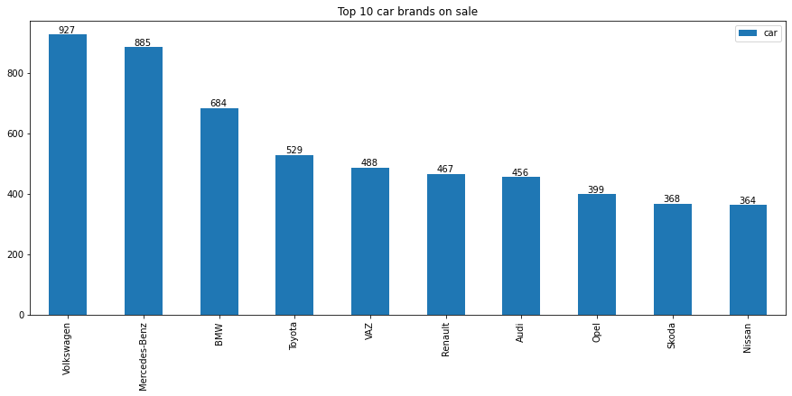

```python
ax = df.head(10).plot.bar(figsize=(15,6))
for p in ax.patches:
    ax.annotate(str(p.get_height()), (p.get_x() + (p.get_width()/4), p.get_height()+5), rotation=0)

plt.title("Top 10 car brands on sale")
plt.show()
```

```python
pip install tk
```

From the dataset, the top performing car sales are from following manufacturers

Volkswagen 927

Mercedes-Benz 885

BMW 684

Toyota 529

VAZ 488

...

# What is the sales trend for top selling car manufacturers?

```python
carsales_year_df = pd.DataFrame(carsales.groupby('year').car.value_counts())
carsales_year_df.rename(columns={'car':'sales'}, inplace=True)
carsales_year_df.reset_index(inplace=True)
```

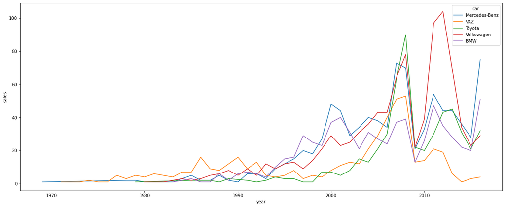

```python
topCarBrandSales = carsales_year_df[carsales_year_df.car.isin(df.head(5).index)]
fig, ax = plt.subplots(figsize=(20,8))
sns.lineplot(data=topCarBrandSales, x='year', y='sales', hue='car')
```

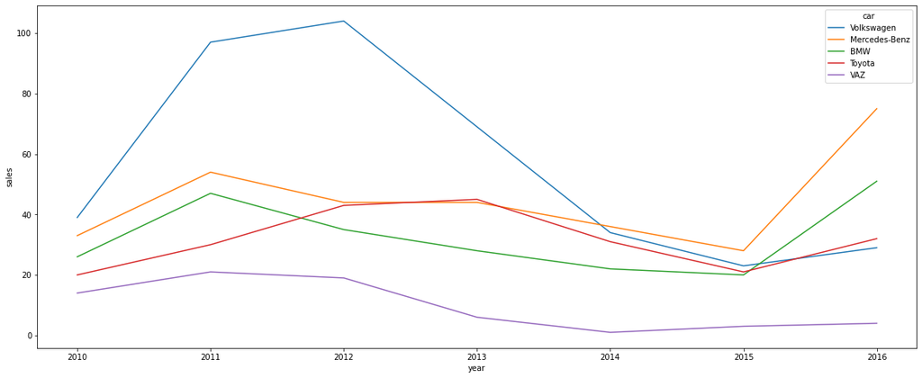

```python
recentCarSalesTopBrands = carsales_year_df[carsales_year_df.car.isin(df.head(5).index) &  (carsales_year_df.year >= 2010)]
fig, ax = plt.subplots(figsize=(20,8))
sns.lineplot(data=recentCarSalesTopBrands, x='year', y='sales', hue='car')
```

# Observations:

1. Overall Volkswagen used car are reported high sales and occupies 1st place, but the saleas are not performing very low in the recent past.
2. Mercedes-Benz significantly performing best sales and followed by BMW. These brands sales are sky rocketed and proven the customer trust.
3. Toyota cars are consistant in sales and keeping their position.
4. On flip side, Volkswagen and Vaz car sales are under performing in recently.

# Which cars gain or loose the market?

```python
#Function that returns perticular year sales

def get_SalesByYear(year):
    return carsales_year_df[carsales_year_df.year == year]


# Function that returns rank of a car

def get_CarSalesRankByYear(r):
    result = get_SalesByYear(r.year).sales.unique()
    i, = np.where(result == r.sales)
    return i[0]+1
```

```python
# Add a new column called 'year_rank' to maintain year wise car sales rank

carsales_year_df['year_rank'] = carsales_year_df.apply(get_CarSalesRankByYear, axis=1)
```

```python
# Top 5 ranked cars from 2009

recenttopcars = carsales_year_df[(carsales_year_df.year_rank <=5) &  (carsales_year_df.year >= 2009)].car.unique()
recenttopcars
```

```
array(['Renault', 'Hyundai', 'Toyota', 'Volkswagen', 'Mercedes-Benz',
       'Mitsubishi', 'Honda', 'BMW', 'Audi', 'Skoda', 'Nissan', 'Ford'],
      dtype=object)
```

```python
topcarbrands = carsales_year_df[(carsales_year_df.year_rank <=5) &  (carsales_year_df.year >= 1980)].car.unique()
topcarbrands
```

```
array(['VAZ', 'Audi', 'Ford', 'Mercedes-Benz', 'Moskvich-AZLK',
       'Volkswagen', 'Lincoln', 'UAZ', 'GAZ', 'Opel', 'BMW', 'Nissan',
       'Toyota', 'Mazda', 'Mitsubishi', 'Volvo', 'Renault', 'Fiat',
       'Peugeot', 'Daewoo', 'Chevrolet', 'Skoda', 'Hyundai', 'Honda'],
      dtype=object)
```

```python
recentCarSalesRanks = carsales_year_df[carsales_year_df.car.isin(recenttopcars) & (carsales_year_df.year >= 2009)]
```

```python
recentCarSalesRanks.pivot_table(index=['year'], columns={'car'}, values='sales')
```

| car year | Audi | BMW | Ford | Honda | Hyundai | Mercedes-Benz | Mitsubishi | Nissan | Renault | Skoda | Toyota | Volkswagen |
| --- | --- | --- | --- | --- | --- | --- | --- | --- | --- | --- | --- | --- |
| 2009 | 16 | 13 | 6 | 18 | 22 | 21 | 19 | 12 | 23 | 15 | 22 | 22 |
| 2010 | 25 | 26 | 20 | 7 | 12 | 33 | 6 | 16 | 24 | 22 | 20 | 39 |
| 2011 | 23 | 47 | 37 | 19 | 60 | 54 | 16 | 25 | 44 | 36 | 30 | 97 |
| 2012 | 19 | 35 | 32 | 17 | 38 | 44 | 12 | 22 | 94 | 60 | 43 | 104 |
| 2013 | 31 | 28 | 38 | 3 | 28 | 44 | 10 | 59 | 35 | 20 | 45 | 69 |
| 2014 | 16 | 22 | 18 | 4 | 9 | 36 | 5 | 29 | 14 | 14 | 31 | 34 |
| 2015 | 13 | 20 | 14 | 3 | 5 | 28 | 2 | 26 | 3 | 6 | 21 | 23 |
| 2016 | 13 | 51 | 14 | 9 | 26 | 75 | 10 | 12 | 14 | 18 | 32 | 29 |

```python
recentCarSalesRanks.pivot_table(index=['year'], columns={'car'}, values='year_rank')
```

| car year | Audi | BMW | Ford | Honda | Hyundai | Mercedes-Benz | Mitsubishi | Nissan | Renault | Skoda | Toyota | Volkswagen |
| --- | --- | --- | --- | --- | --- | --- | --- | --- | --- | --- | --- | --- |
| 2009 | 6 | 8 | 12 | 5 | 2 | 3 | 4 | 9 | 1 | 7 | 2 | 2 |
| 2010 | 4 | 3 | 7 | 13 | 10 | 2 | 14 | 8 | 5 | 6 | 7 | 1 |
| 2011 | 10 | 4 | 6 | 12 | 2 | 3 | 15 | 9 | 5 | 7 | 8 | 1 |
| 2012 | 12 | 7 | 8 | 14 | 6 | 4 | 16 | 11 | 2 | 3 | 5 | 1 |
| 2013 | 8 | 9 | 5 | 22 | 9 | 4 | 16 | 2 | 6 | 11 | 3 | 1 |
| 2014 | 7 | 5 | 6 | 14 | 9 | 1 | 13 | 4 | 8 | 8 | 3 | 2 |
| 2015 | 7 | 5 | 6 | 13 | 11 | 1 | 14 | 2 | 13 | 10 | 4 | 3 |
| 2016 | 8 | 2 | 7 | 11 | 5 | 1 | 10 | 9 | 7 | 6 | 3 | 4 |

**Q)Analyse the sales of each brand**

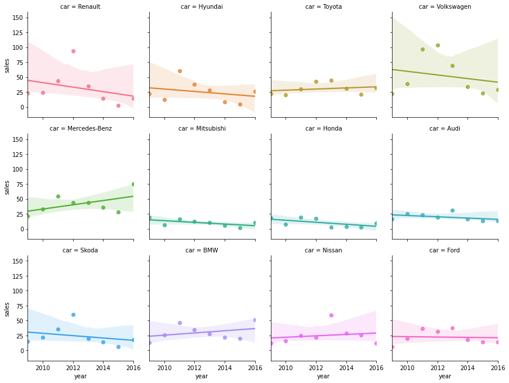

```python
sns.lmplot(data=recentCarSalesRanks, x='year', y='sales', col='car', fit_reg=True, hue='car', col_wrap=4, height=3)
```

We can divide brandsales in three categories

i)increasing

ii)no change

ii)decreasing

The brands which show an increasing sales are Toyota,Mercedes-Benz,BMW,Nissan,

The brands which show decreasing sales are Renault,Volkswagen,Mitsubishi,Honda,Skoda

Brands which show no change are Ford,Audi

**Q)Analyse the rank of each brand**

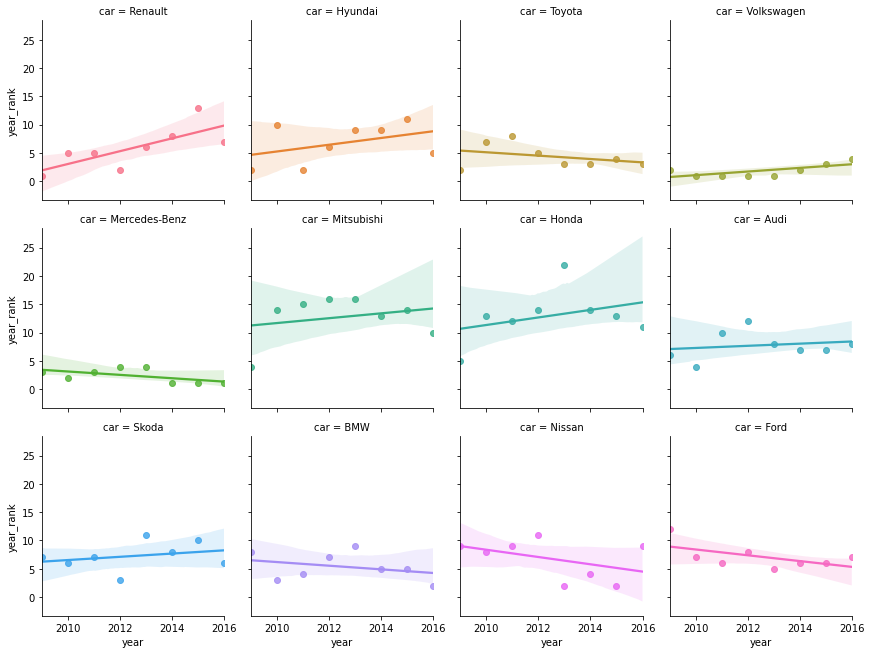

```python
sns.lmplot(data=recentCarSalesRanks, x='year', y='year_rank', col='car', fit_reg=True, hue='car', col_wrap=4, height=3)
```

# We can divide brands ranks in three categories

i)increasing

ii)no change

iii)decreasing

the brands which show a decreasing trend are Toyota, BMW.

the brand which show a neutral trend is audi

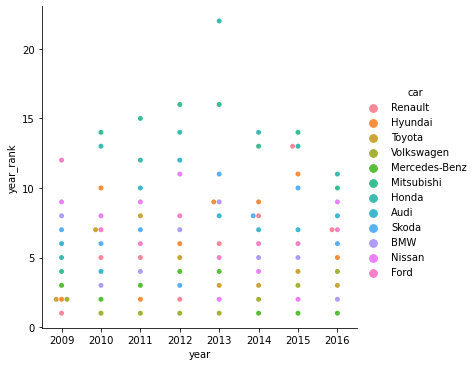

```python
sns.catplot(x="year", y="year_rank", hue="car", kind="swarm", data=recentCarSalesRanks)
```

```python
topcarbrands = pd.DataFrame(topcarbrands)
topcarbrands.rename(columns={0:'car'}, inplace=True)
```

```python
def get_IsTopSelling(r):
    return r.car in recenttopcars

topcarbrands['is_top_selling'] = topcarbrands.apply(get_IsTopSelling, axis=1)
```

```python
print(topcarbrands[topcarbrands.is_top_selling == False].car, topcarbrands[topcarbrands.is_top_selling == True].car)
```

```
0               VAZ
4     Moskvich-AZLK
6           Lincoln
7               UAZ
8               GAZ
9              Opel
13            Mazda
15            Volvo
17             Fiat
18          Peugeot
19           Daewoo
20        Chevrolet
Name: car, dtype: object 1              Audi
2              Ford
3     Mercedes-Benz
5        Volkswagen
10              BMW
11           Nissan
12           Toyota
14       Mitsubishi
16          Renault
21            Skoda
22          Hyundai
23            Honda
Name: car, dtype: object
```

# Observations: Following are the brands which loose the market

VAZ

Moskvich-AZLK

Lincoln

UAZ

GAZ

Opel

Mazda

Volvo

Fiat

Peugeot

Daewoo

Chevrolet

# Following are the brands which gain/sustain the market

Audi

Ford

Mercedes-Benz

Volkswagen

BMW

Nissan

Toyota

Mitsubishi

Renault

Skoda

Hyundai

Honda

# What are the top 10 Pemium cars & models and their sales?

```python
carsales[carsales.price.isin(carsales.price.nlargest(10))].sort_values('price', ascending=False)
```

|  | car | price | body | mileage | engV | engType | registration | year | model | drive |
| --- | --- | --- | --- | --- | --- | --- | --- | --- | --- | --- |
| 7621 | Bentley | 547800.0 | sedan | 20.0 | 6.75 | Petrol | yes | 2016 | Mulsanne | rear |
| 1611 | Bentley | 499999.0 | crossover | 20.0 | 6.00 | Petrol | yes | 2016 | Bentayga | full |
| 2637 | Bentley | 449999.0 | crossover | 1.0 | 6.00 | Petrol | yes | 2016 | Bentayga | full |
| 4134 | Bentley | 449999.0 | crossover | 20.0 | 6.00 | Petrol | yes | 2016 | Bentayga | full |
| 4325 | Mercedes-Benz | 300000.0 | sedan | 68.0 | 6.00 | Petrol | yes | 2011 | S 600 | rear |
| 5849 | Mercedes-Benz | 300000.0 | other | 37.0 | 5.00 | Petrol | yes | 2012 | G 500 | full |
| 1891 | Mercedes-Benz | 295000.0 | sedan | 29.0 | 6.00 | Petrol | yes | 2011 | S 600 | rear |
| 2165 | Mercedes-Benz | 295000.0 | sedan | 29.0 | 6.00 | Petrol | yes | 2011 | S-Guard | rear |
| 8205 | Land Rover | 285000.0 | crossover | 80.5 | 5.00 | Petrol | yes | 2016 | Range Rover | full |
| 1478 | Bentley | 259000.0 | sedan | 415.0 | 6.00 | Petrol | yes | 2014 | Flying Spur | full |

```python
cars_with_max_price_df = pd.DataFrame(carsales.groupby('car').price.max())
cars_with_max_price_df.reset_index(inplace=True)
cars_with_max_price_df.rename(columns={'price':'max_price'}, inplace=True)
```

```python
def get_totalcarsales(r):
    return carsales[(carsales.car == r.car) & (carsales.price == r.max_price)].car.count()

def get_latestyearofsale(r):
    return carsales[(carsales.car == r.car) & (carsales.price == r.max_price)].year.max()
```

```python
cars_with_max_price_df['total_sales'] = cars_with_max_price_df.apply(get_totalcarsales, axis=1)
cars_with_max_price_df['recently_sold_on'] = cars_with_max_price_df.apply(get_latestyearofsale, axis=1)
```

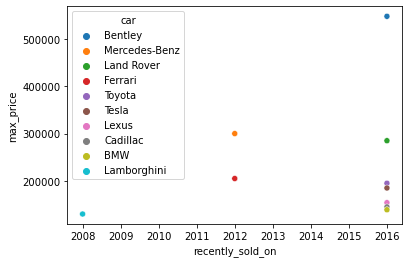

```python
sns.scatterplot(data=cars_with_max_price_df.sort_values('max_price', ascending=False).head(10), x='recently_sold_on', y='max_price', hue='car')
```

# Observations: Top 10 premium car's sales reported as follows.

Bentley

Mulsanne

Bentayga

Flying Spur

Mercedes-Benz S 600 G 500 S-Guard

Land Rover

Range Rover

# Sales of these cars gives interesting result.

-->Though Mercedes-Benz and Land Rover are proven strength in sales under Premium sector, neverthless Bentley dominating recently in this segment. -->Following cars are reported premium car sales in recent years: Bentley

Mercedes-Benz

Land Rover

Ferrari

Toyota

Tesla

Lexus

Cadillac

BMW

Lamborghini

--->But latest reported high priced cars sold as below.

*Lamborghini - 2008

*Mercedes-Benz & Ferrari - 2012

-->There are no such high priced cars sold from 2013 till 2015

-->Tremendus sales reported in 2016 for these super premium cars by **Bentley, Land Rover, Toyota, Tesla, Lexus, Cardillac & BMW**

Preferred to have **full** wheel and **rear** wheel drive

All these premium cars engine type is **Petrol**

# What are the sales & revenue in each segment of class ?

```python
'''
Fuction that computes the class of the car based on price
Rules:
    -- Economy --> Price less than 10000
    -- Luxury  --> Price above 10000 and below 30000
    -- Premium --> Price above 30000
'''
def classify_class(r):
    if r.price <= 10000:
        return "Economy"
    elif (r.price > 10000) & (r.price <= 30000):
        return "Luxury"
    else:
        return "Premium"

    # Set new column called 'class' for defining the sement

carsales["class"] = carsales.apply(classify_class, axis=1)
```

```python
carsales.head()
```

|  | car | price | body | mileage | engV | engType | registration | year | model | drive | class |
| --- | --- | --- | --- | --- | --- | --- | --- | --- | --- | --- | --- |
| 0 | Ford | 15500.0 | crossover | 68.0 | 2.50 | Gas | yes | 2010 | Kuga | full | Luxury |
| 1 | Mercedes-Benz | 20500.0 | sedan | 173.0 | 1.80 | Gas | yes | 2011 | E-Class | rear | Luxury |
| 2 | Mercedes-Benz | 35000.0 | other | 135.0 | 5.50 | Petrol | yes | 2008 | CL 550 | rear | Premium |
| 3 | Mercedes-Benz | 17800.0 | van | 162.0 | 1.80 | Diesel | yes | 2012 | B 180 | front | Luxury |
| 4 | Mercedes-Benz | 33000.0 | vagon | 91.0 | 2.57 | Other | yes | 2013 | E-Class | rear | Premium |

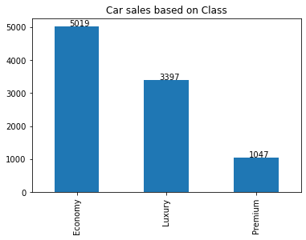

```python
ax = carsales["class"].value_counts().plot.bar(figsize=(6,4))
for p in ax.patches:
    ax.annotate(str(p.get_height()), (p.get_x() + (p.get_width()/3), p.get_height()+10), rotation=0)

plt.title("Car sales based on Class")
```

```
AxesSubplot(0.260833,0.125;0.503333x0.755)
```

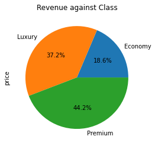

```python
revenueByClass_df = carsales.groupby('class').price.sum()
plt.title('Revenue against Class')
print(revenueByClass_df.plot.pie(autopct='%1.1f%%'))
```

# Observations:

-->Economy Cars are best selling segment followed by Luxury and Premium -->Though the economy car sales are predominant in sales, but revenues are not impressive.

Economy - 18.6%

Luxury - 37.2%

Premium - 44.2%

# What is the revenue generated in each segment of class ?

```python
pvt_classyear_sales = carsales.pivot_table(index=['year','class'],  values="car", aggfunc='count')
pvt_classyear_sales.reset_index(inplace=True)
pvt_classyear_sales.rename(columns={"car":"car_sales"}, inplace=True)
```

```python
# Function that returns revenue of a perticular segment in a specific year

def get_revenuebyclass(r):
    return carsales[(carsales['class'] == r['class']) & (carsales.year == r.year)].price.sum()
```

```python
pvt_classyear_sales['revenue'] = pvt_classyear_sales.apply(get_revenuebyclass, axis=1)
```

```python
def get_detailsbyclass(cls):
    return pvt_classyear_sales[pvt_classyear_sales['class'] == cls]

def get_detailsbyclass(cls, year):
    return pvt_classyear_sales[(pvt_classyear_sales['class'] == cls) & (pvt_classyear_sales.year >= year)]
```

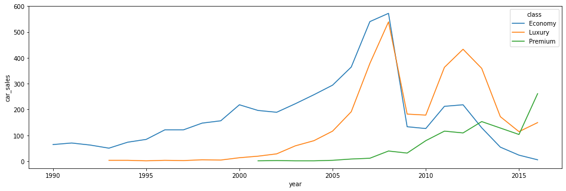

```python
fig, ax = plt.subplots(figsize=(16,5))
sns.lineplot(data=pvt_classyear_sales[pvt_classyear_sales.year >= 1990], x='year', y='car_sales', hue='class')
```

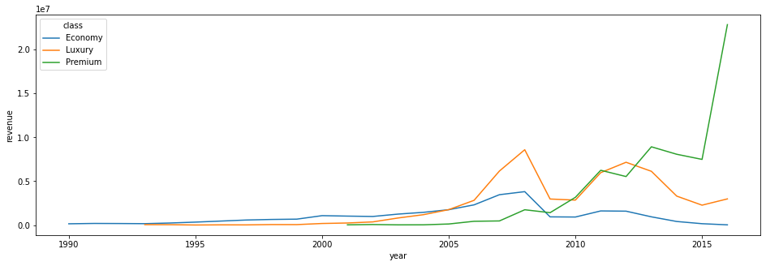

```python
fig, ax = plt.subplots(figsize=(16,5))
sns.lineplot(data=pvt_classyear_sales[pvt_classyear_sales.year >= 1990], x='year', y='revenue', hue='class')
```

# OBSERVATION

From the above charts, it is evedent that, Economy car sales are comes to '0', Luxury and Premium takes the momentum of high sales.

In addition the revenue generated by Premium cars is 500% higher than other cars in recent year.

So possible reason of reduced sales due to ground touching Economy class car sales.

# What is the sales trend based on body ?

```python
carsalesbybody_df = carsales.pivot_table(index=['body'],  values="car", aggfunc='count')
carsalesbybody_df.reset_index(inplace=True)
carsalesbybody_df.rename(columns={'car':'sales'}, inplace=True)
```

```python
recent_carsalesbybody_df = carsales[carsales.year > 2010].pivot_table(index=['body'],  values="car", aggfunc='count')
recent_carsalesbybody_df.reset_index(inplace=True)
recent_carsalesbybody_df.rename(columns={'car':'sales'}, inplace=True)
```

```python
pvt_bodyyear_sales = carsales.pivot_table(index=['year','body'],  values="car", aggfunc='count')
pvt_bodyyear_sales.rename(columns={"car":"car_sales"}, inplace=True)
pvt_bodyyear_sales.reset_index(inplace=True)

def get_sales_by_body(body):
    return pvt_bodyyear_sales[pvt_bodyyear_sales['body'] == body]

# crossover, sedan, van, vagon, hatch, other
```

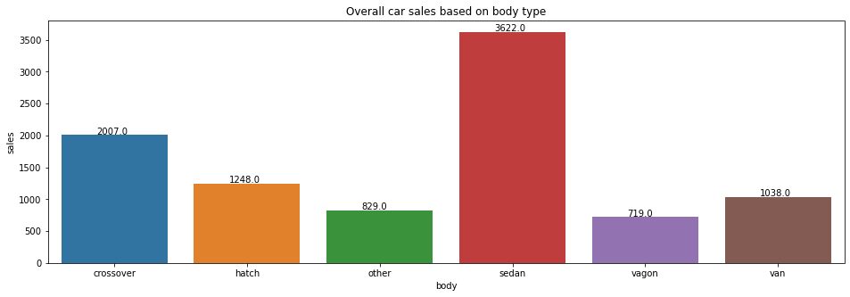

```python
fig, ax = plt.subplots(figsize=(16,5))
sns.barplot(data=carsalesbybody_df, x='body', y='sales')

for p in ax.patches:
    ax.annotate(str(p.get_height()), (p.get_x() + (p.get_width()/3), p.get_height()+10), rotation=0)

plt.title('Overall car sales based on body type')
```

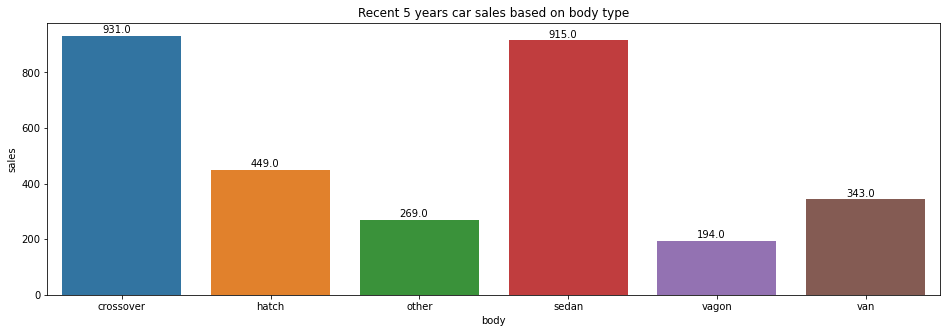

```python
fig, ax = plt.subplots(figsize=(16,5))
sns.barplot(data=recent_carsalesbybody_df, x='body', y='sales')

for p in ax.patches:
    ax.annotate(str(p.get_height()), (p.get_x() + (p.get_width()/3), p.get_height()+10), rotation=0)

plt.title('Recent 5 years car sales based on body type')
```

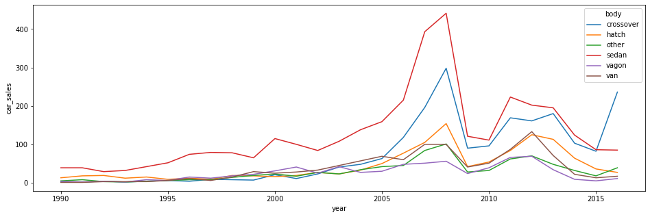

```python
fig, ax = plt.subplots(figsize=(16,5))
sns.lineplot(data=pvt_bodyyear_sales[pvt_bodyyear_sales.year >= 1990], x='year', y='car_sales', hue='body')
```

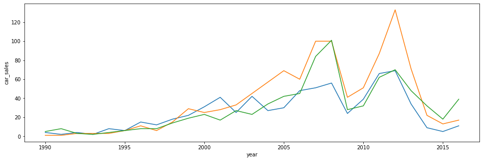

```python
fig, ax = plt.subplots(figsize=(16,5))
sns.lineplot(data=pvt_bodyyear_sales[(pvt_bodyyear_sales.year >= 1990) & (pvt_bodyyear_sales.body == 'vagon')], x='year', y='car_sales')
sns.lineplot(data=pvt_bodyyear_sales[(pvt_bodyyear_sales.year >= 1990) & (pvt_bodyyear_sales.body == 'van')], x='year', y='car_sales')
sns.lineplot(data=pvt_bodyyear_sales[(pvt_bodyyear_sales.year >= 1990) & (pvt_bodyyear_sales.body == 'other')], x='year', y='car_sales')
```

# Observations:

1. Overall Crossover, Sedan and hatches are more demanded car body types
2. It is observed that recent crossover sales are skyrocketing.
3. Van and Vagon body types are loosing sales and other cars are gaining market.
4. So possible reason of declining sales are Van & Vagon type cars are loosing market.

# What are the best mileage cars in each segment of 'class' ?

```python
besteconomycars = carsales.pivot_table(index=['class','car'],  values="mileage", aggfunc='max')
besteconomycars.reset_index(inplace=True)
```

```python
# Return upper whisker for mileage by class
def get_best_carandmileage_byclass(cls):
    clsmileage = besteconomycars[besteconomycars['class'] == cls]
    maxval = clsmileage.mileage.max()
    thirdQurtile = clsmileage.describe().iloc[6].mileage
    firstQurtile = clsmileage.describe().iloc[4].mileage
    iqr = thirdQurtile - firstQurtile
    upperwhisker = min(maxval, thirdQurtile + (1.5 * iqr))
    return upperwhisker

# Get closest upper whisker milage results
def get_closest(cls, val):
    cls_df = carsales[carsales['class'] == cls]
    return cls_df.iloc[(cls_df['mileage']-val).abs().argsort()[:2]]
```

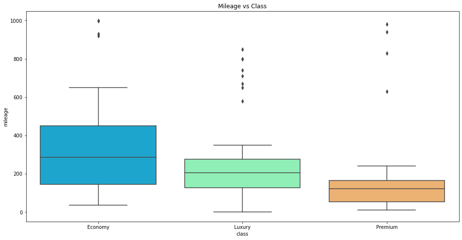

```python
plt.figure(figsize=(16, 8))
sns.boxplot(data=besteconomycars, x='class', y='mileage', palette='rainbow')

plt.title('Mileage vs Class')
```

```python
print(besteconomycars[besteconomycars['class'] == 'Economy'].describe())
print('---------------------')
print(besteconomycars[besteconomycars['class'] == 'Luxury'].describe())
print('---------------------')
print(besteconomycars[besteconomycars['class'] == 'Premium'].describe())
```

```
          mileage
count   73.000000
mean   317.383562
std    224.147684
min     37.000000
25%    145.000000
50%    286.000000
75%    450.000000
max    999.000000
---------------------
          mileage
count   52.000000
mean   258.346154
std    221.197621
min      1.000000
25%    128.000000
50%    206.500000
75%    276.250000
max    850.000000
---------------------
          mileage
count   37.000000
mean   187.540541
std    244.048276
min     11.000000
25%     55.000000
50%    122.000000
75%    165.000000
max    980.000000
```

```python
get_closest('Economy', get_best_carandmileage_byclass('Economy'))
```

|  | car | price | body | mileage | engV | engType | registration | year | model | drive | class |
| --- | --- | --- | --- | --- | --- | --- | --- | --- | --- | --- | --- |
| 4572 | Kia | 7150.0 | hatch | 920.0 | 1.4 | Petrol | yes | 2008 | Ceed | front | Economy |
| 7970 | ZAZ | 1600.0 | sedan | 930.0 | 1.2 | Gas | yes | 2006 | 1103 Ñëàâóòà | front | Economy |

```python
get_closest('Luxury', get_best_carandmileage_byclass('Luxury'))
```

|  | car | price | body | mileage | engV | engType | registration | year | model | drive | class |
| --- | --- | --- | --- | --- | --- | --- | --- | --- | --- | --- | --- |
| 898 | Volkswagen | 12900.0 | other | 440.0 | 1.4 | Petrol | yes | 2008 | Eos | front | Luxury |
| 5009 | Mercedes-Benz | 12300.0 | sedan | 423.0 | 5.0 | Gas | yes | 1997 | S 500 | rear | Luxury |

```python
get_closest('Premium', get_best_carandmileage_byclass('Premium'))
```

|  | car | price | body | mileage | engV | engType | registration | year | model | drive | class |
| --- | --- | --- | --- | --- | --- | --- | --- | --- | --- | --- | --- |
| 1033 | Mercedes-Benz | 32000.0 | van | 255.0 | 3.0 | Diesel | yes | 2008 | Sprinter 318 ïàññ. | rear | Premium |
| 8948 | Mercedes-Benz | 32500.0 | crossover | 254.0 | 3.2 | Diesel | yes | 2008 | GL 320 | full | Premium |

# Observations:

Following are the best mileage given cars in each segment.

1. Economy --> Kia - Ceed & ZAZ - 1103
2. Luxury --> Volkswagen - Eos & Mercedes-Benz - S 500
3. Premium --> Mercedes-Benz - Sprinter 318 & GL 320

# Used car registrations by class

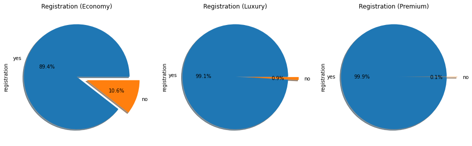

```python
f,ax = plt.subplots(1,3,figsize=(16,8))
carsales[carsales['class'] == 'Economy'].registration.value_counts().plot.pie(explode=[0,0.2],autopct='%1.1f%%',ax=ax[0],shadow=True)
carsales[carsales['class'] == 'Luxury'].registration.value_counts().plot.pie(explode=[0,0.2],autopct='%1.1f%%',ax=ax[1],shadow=True)
carsales[carsales['class'] == 'Premium'].registration.value_counts().plot.pie(explode=[0,0.2],autopct='%1.1f%%',ax=ax[2],shadow=True)
ax[0].set_title('Registration (Economy)')
ax[1].set_title('Registration (Luxury)')
ax[2].set_title('Registration (Premium)')
```

# Observations:

Majority of unregistered cars were from Economy class

# Derive the correlation between sales and other values ?

**Class wise car prices**

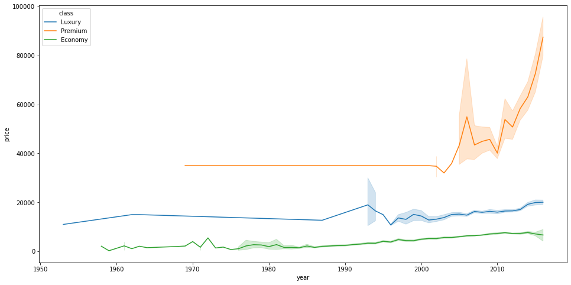

```python
plt.figure(figsize=(16,8))
sns.lineplot(data=carsales, x='year', y='price', hue='class')
```

**Engine Type wise car prices**

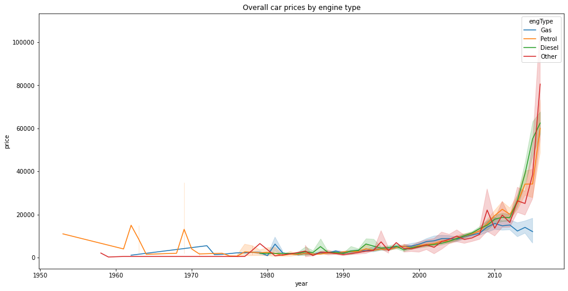

```python
plt.figure(figsize=(16,8))
sns.lineplot(data=carsales, x='year', y='price', hue='engType')
plt.title("Overall car prices by engine type")
```

```python
# For last 10 years car sales based on engType, body, class and average price

salesByEngTypeBodyClass_df = carsales[carsales.year.isin(pd.DataFrame(carsales.year.unique())[0].nlargest(10))]
salesByYearBodyClass = salesByEngTypeBodyClass_df.pivot_table(index=['year','engType'], values='price', aggfunc='mean')
salesByYearBodyClass.reset_index(inplace=True)
```

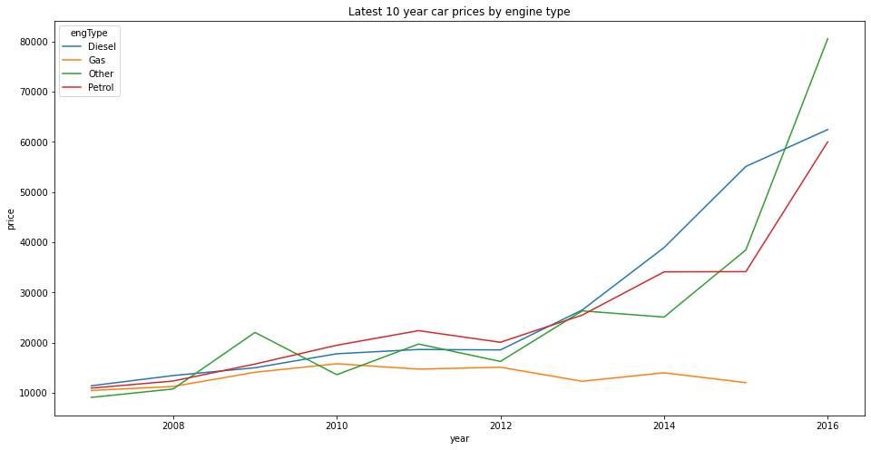

```python
plt.figure(figsize=(16,8))
sns.lineplot(data=salesByYearBodyClass, x='year', y='price', hue='engType')
plt.title("Latest 10 year car prices by engine type")
```

```python
classsalesByEngType_5year = carsales[carsales.year.isin(pd.DataFrame(carsales.year.unique())[0].nlargest(10))].groupby('year')['engType'].value_counts()
carsalesEngType = pd.DataFrame(classsalesByEngType_5year)
carsalesEngType.rename(columns={'engType':'sales'}, inplace=True)
carsalesEngType.reset_index(inplace=True)
```

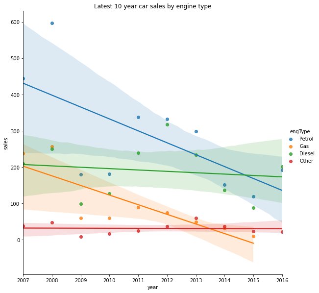

```python
sns.lmplot(data=carsalesEngType, x='year', y='sales', hue='engType', height=8)
plt.title("Latest 10 year car sales by engine type")
```

[figure not shown]

```python
fig, ax = plt.subplots(figsize=(16,8))

sns.barplot(x="engType", y="price", hue= "body", palette="husl",data=carsales)
ax.set_title("Average price of vehicles by engine type and drive",fontdict= {'size':12})
ax.xaxis.set_label_text("Type Of Fuel",fontdict= {'size':14})
ax.yaxis.set_label_text("Average Price",fontdict= {'size':14})
ticks = plt.setp(ax.get_xticklabels(),rotation=90)
```

**car sales by drive**

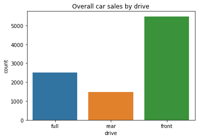

```python
#fig, ax = plt.subplots(figsize=(16,8))
sns.countplot(x='drive', data=carsales, orient='h')
plt.title("Overall car sales by drive")
```

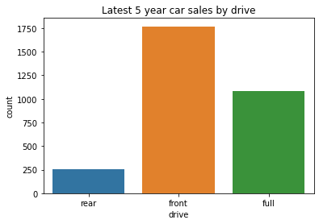

```python
#fig, ax = plt.subplots(figsize=(16,8))
sns.countplot(x='drive', data=carsales[carsales.year > 2010], orient='h')
plt.title("Latest 5 year car sales by drive")
```

**Yearly car price and sales by engine type**

```python
def get_carpricesales(et):
    return salesByYearBodyClass[salesByYearBodyClass.engType == et]

def get_priceByYearEngType(r):
    return carsales[(carsales.year == r.year) & (carsales.engType == r.engType)].car.count()

def plotGraph(et):
    carSalesPrice = get_carpricesales(et)
    plt.figure(figsize=(20, 8))
    ax = carSalesPrice.plot('year','sales')
    carSalesPrice.plot('year','price',secondary_y=True, ax=ax)
    plt.legend()
```

```python
salesByYearBodyClass['sales'] = salesByYearBodyClass.apply(get_priceByYearEngType, axis=1)
```

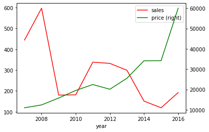

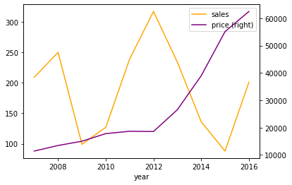

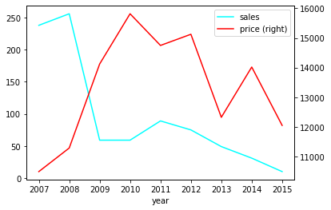

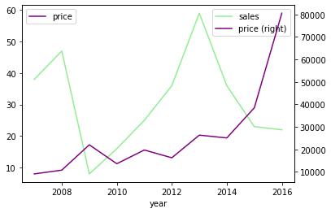

```python
petrolcarSalesPrice = get_carpricesales('Petrol')
dieselCarSalesPrice = get_carpricesales('Diesel')
gasCarSalesPrice = get_carpricesales('Gas')
otherCarSalesPrice = get_carpricesales('Other')

plt.figure(figsize=(16, 8))
ax = petrolcarSalesPrice.plot('year','sales', color='r')
petrolcarSalesPrice.plot('year','price', color='g', secondary_y=True, ax=ax)

ax = dieselCarSalesPrice.plot('year','sales', color='orange')
dieselCarSalesPrice.plot('year','price', color='purple', secondary_y=True, ax=ax)

ax = gasCarSalesPrice.plot('year','sales', color='aqua')
gasCarSalesPrice.plot('year','price', color='red', secondary_y=True, ax=ax)

ax = otherCarSalesPrice.plot('year','sales', color='lightgreen')
otherCarSalesPrice.plot('year','price', color='purple', secondary_y=True, ax=ax)

plt.legend()
```